# Stress Experiment Analysis Report

G. Brett Moreau

February 1, 2021

### Introduction

This analysis will focus on the Stress component of the Gautier TUMI Pilot project. This experiment focuses on the effect of stress on intestinal microbiota diversity and composition. Previous work in the lab has identified several changes in the microbiota, particularly *Lactobacillus ssp.*, that are associated with stress. This experiment will investigate this in a different set of samples to confirm reproducibility and identify other features associated with stress.

### Characterization of the Data Set

There are 24 samples in this experiment.Samples were divided into two groups (Naive and Stressed) and two different timepoints (pre- and post-stress intervention). Each treatment group and timepoint is divided into 6 samples each. A total of 1795 Amplicon Sequence Variants (ASVs), or unique read sequences, were identified in these 24 samples.

Below is a general overview of the total number of reads in the data set, the mean and median number of reads/sample, and the range of reads across this data set.

```r
sum(total.reads)
```

```
## [1] 1741609
```

```r
mean(total.reads)
```

```
## [1] 72567.04
```

```r
median(total.reads)
```

```
## [1] 71421.5
```

```r
range(total.reads)
```

```
## [1]  43957 117986
```

### Alpha Diversity

I’ll first investigate alpha diversity, which examines diversity within a given sample. Alpha diversity consists of two major measures:

- **Richness**: the number of taxonomic groups within a given sample.
- **Evenness**: how evenly abundances of taxonomic groups are distributed in a given sample.

The DADA2 pipeline removes singlets (sequences detected only once) from the data set, as it does not have enough confidence to determine whether these sequences are real or artifacts. Because of this, measures of richness fail explicitly and are difficult to interpret. I’ll focus mainly on measures of evenness but give measures of richness a glance to see if there are any major differences.

#### Richness

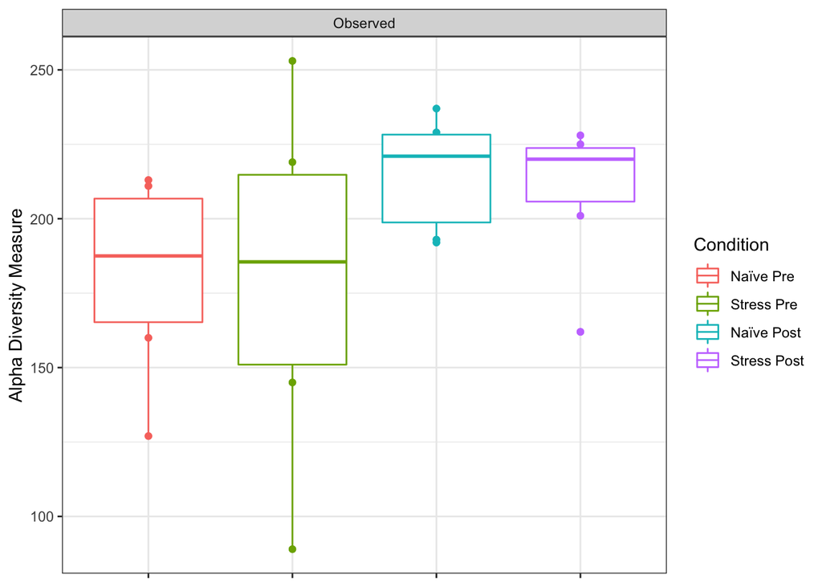

```
##
##  Pairwise comparisons using Wilcoxon rank sum exact test
##
## data:  richness$Observed and sample_data(ps.stress)$Condition
##
##             Naïve Pre Stress Pre Naïve Post
## Stress Pre  1.00      -          -
## Naïve Post  0.39      1.00       -
## Stress Post 0.39      1.00       1.00
##
## P value adjustment method: bonferroni
```

There are no major differences in richness between groups.

#### Evenness

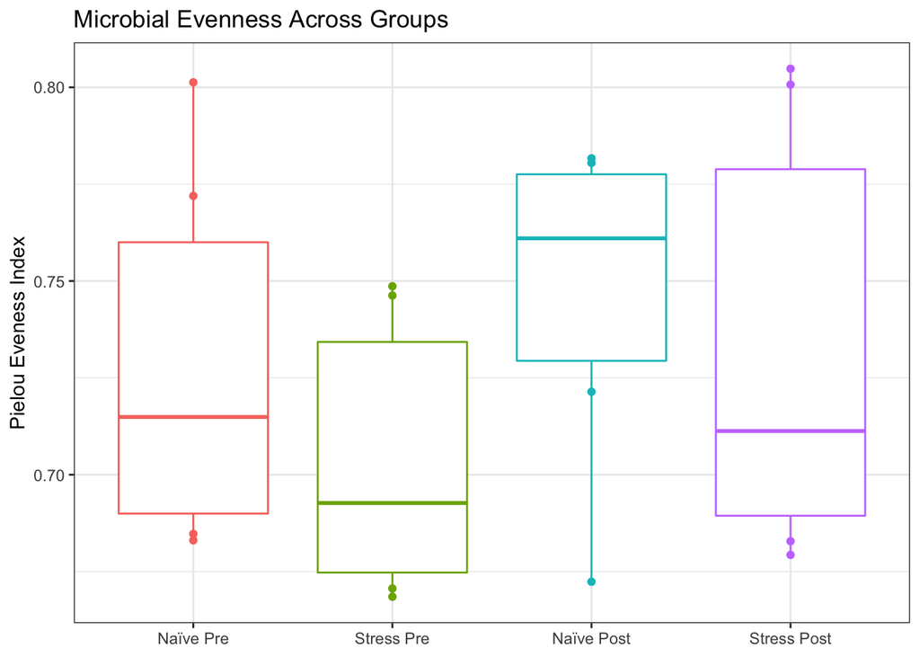

```
##
##  Pairwise comparisons using Wilcoxon rank sum exact test
##
## data:  evenness$pielou and sample_data(ps.stress)$Condition
##
##             Naïve Pre Stress Pre Naïve Post
## Stress Pre  1.00      -          -
## Naïve Post  1.00      0.39       -
## Stress Post 1.00      1.00       1.00
##
## P value adjustment method: bonferroni
```

There are also no major differences in evenness between groups. Overall, this suggests that stress does not drive differences in alpha diversity.

### Beta Diversity

I’ll now investigate differences in beta diversity, or diversity between different samples in the experiment. I’ll use Bray-Curtis Dissimilarity as my measure for beta diversity in this study, and I’ll use Non-metric Multidimensional Scaling (NMDS) to visualize dissimilarity distances between samples.

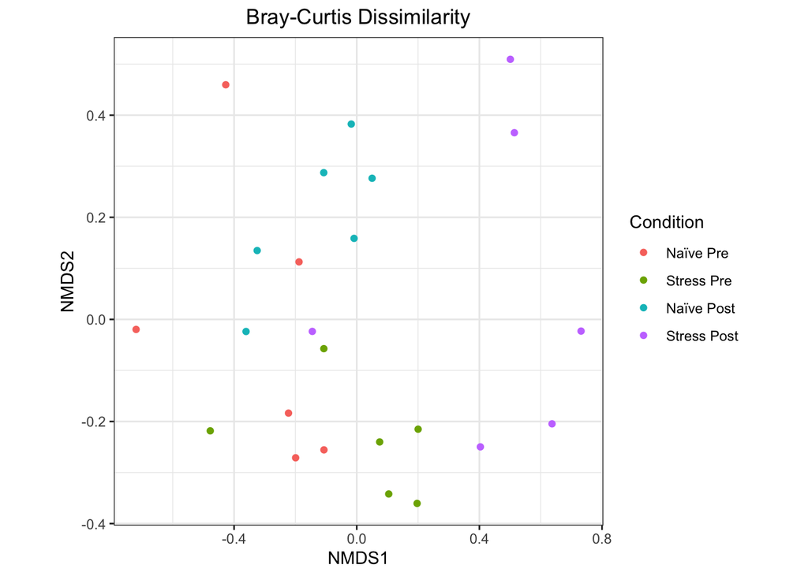

Samples do not cluster into as clear of groups as seen with the Mucin supplementation experiment. However, there does appear to be some clustering berween groups. I’ll perform a PERMANOVA to test for differences in clustering between groups.

| combinations | permanova.p.bray | permanova.FDR.bray |
| --- | --- | --- |
| Naïve Pre/Naïve Post | 0.07 | 0.42 |
| Naïve Pre/Stress Pre | 0.026 | 0.156 |
| Naïve Pre/Stress Post | 0.002 | 0.012 |
| Naïve Post/Stress Pre | 0.002 | 0.012 |
| Naïve Post/Stress Post | 0.009 | 0.054 |
| Stress Pre/Stress Post | 0.008 | 0.048 |

### Changes in Community Composition

There appear to be some broad differences in diversity between groups. I’ll now see if this is reflected by any broad changes in community composition across groups. I’ll start by looking at the phylum level, then move on to differences at the Family level. This analysis will focus on taxa that make up at least 1% of the relative abundance in at least one group.

#### Phylum-Level Community Composition

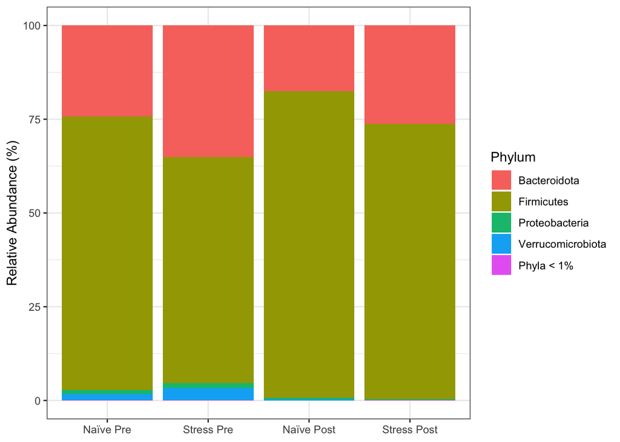

At the Phylum level, samples were dominated by members of the *Bacteroidota* and *Firmicutes* phyla. Samples from the Naive group tended to have higher relative abundances of *Firmicutes* compared to samples from the Stressed Group at both timepoints.

#### Family-Level Community Composition

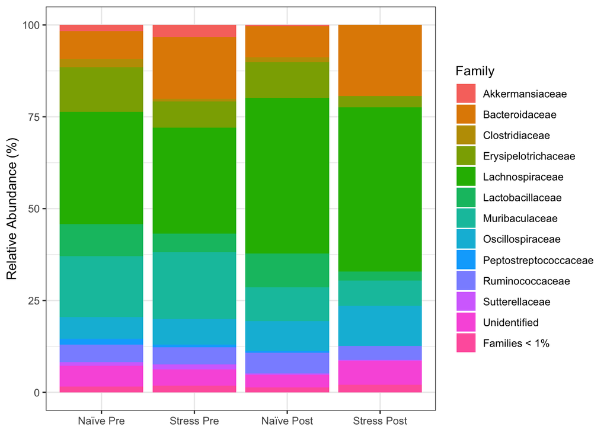

Distribution of different Families appears to vary across different groups. I’ll now look at the relative abundance of each family across groups to better visualize differences.

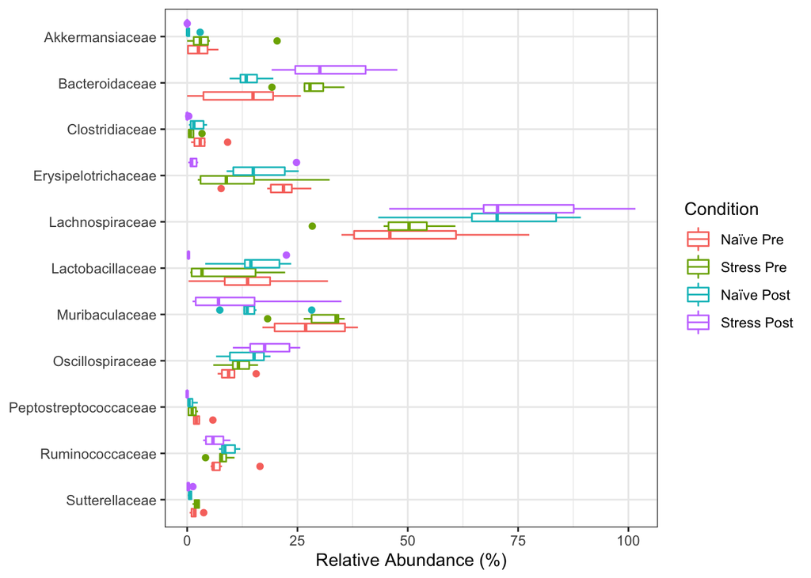

### Selection of ASVs that Distinguish Between Groups

I’ve broadly looked at differences in diversity and community composition with the Naive vs. Stress experiment. I’ll now move on to identify ASVs that best discriminate between groups. For this analysis I’ll focus on comparing the Stressed samples from Pre- and Post- conditions, as these are most comparable to the Baseline vs. 3 Week Stress samples from the Mucin supplementation experiment. ASVs will be selected by generating Random Forest models for each comparison. Because of the small sample size (n = 6 per group), I’ll forego using training/test sets and build the Random Forest model on the entire data set.

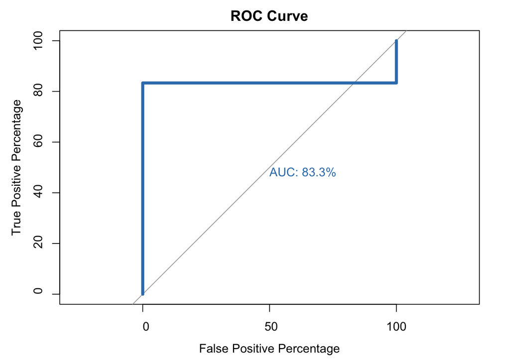

```
##
## Call:
## roc.default(response = outcome.time, predictor = model.rf.stress.time.final$votes[,     1], percent = TRUE, plot = TRUE, legacy.axes = TRUE, main = "ROC Curve",     xlab = "False Positive Percentage", ylab = "True Positive Percentage",     col = "#377eb8", lwd = 4, print.auc = TRUE)
##
## Data: model.rf.stress.time.final$votes[, 1] in 6 controls (outcome.time Stress Pre) > 6 cases (outcome.time Stress Post).
## Area under the curve: 83.33%
```

This model performed well, but had less accuracy than previous models with larger sample sizes. The generated model had an Out-of-Bag error rate of 8.33%, and the overall AUC of the model is 83.3%. One caveat is that because the model was generated on the entire data set, we can’t test it to see how well it predicts samples from a different data set.

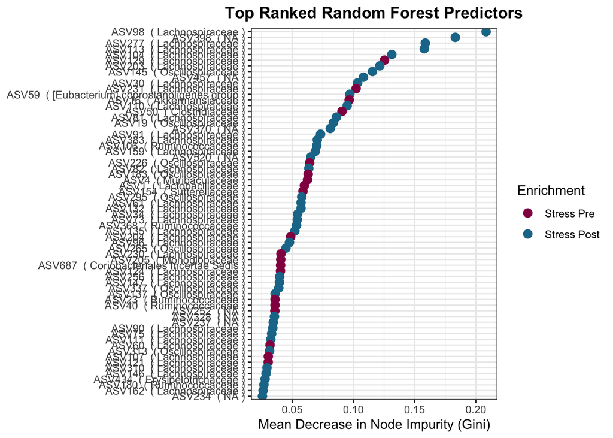

Several ASVs were identified that distinguish between Pre- and Post-Stressed groups. Many of these ASVs were from the Family *Lachnospiraceae*, with many (but not all) of these ASVs enriched in the Post-Stress condition.

### Overlap Between ASVs From Stress and Mucin Experiments

While the Mucin supplementation experiment looks at the effect of mucin supplementation on stress, the “Baseline” and “3 Weeks” samples are identical to the “Stress Pre” and “Stress Post” groups in this experiment. Therefore, I’ll look for overlap between the ASVs that discriminate in each experiment.

| OTU | Stress.Mean.Decrease.Gini | Pre.vs.Post.Mean.Decrease.Gini | Stress.RF.Rank | Pre.Post.RF.Rank | Enrichment.Stress | Enrichment.Pre.Post | Kingdom | Phylum | Class | Order | Family | Genus | ASV.Family |
| --- | --- | --- | --- | --- | --- | --- | --- | --- | --- | --- | --- | --- | --- |
| ASV104 | 0.4641383 | 0.1313286 | 5 | 5 | 3 Wk Stress | Stress Post | Bacteria | Firmicutes | Clostridia | Lachnospirales | Lachnospiraceae | NA | ASV104 ( Lachnospiraceae ) |
| ASV129 | 0.2163053 | 0.1253413 | 18 | 6 | Baseline | Stress Pre | Bacteria | Firmicutes | Clostridia | Lachnospirales | Lachnospiraceae | Lachnoclostridium | ASV129 ( Lachnospiraceae ) |
| ASV59 | 0.2071447 | 0.0970238 | 21 | 12 | 3 Wk Stress | Stress Post | Bacteria | Firmicutes | Clostridia | Oscillospirales | [Eubacterium] coprostanoligenes group | NA | ASV59 ( [Eubacterium] coprostanoligenes group ) |
| ASV50 | 0.5335158 | 0.0906389 | 3 | 15 | Baseline | Stress Pre | Bacteria | Firmicutes | Clostridia | Clostridiales | Clostridiaceae | Clostridium sensu stricto 1 | ASV50 ( Clostridiaceae ) |
| ASV159 | 0.6204478 | 0.0688548 | 2 | 22 | 3 Wk Stress | Stress Post | Bacteria | Firmicutes | Clostridia | Lachnospirales | Lachnospiraceae | Lachnospiraceae UCG-001 | ASV159 ( Lachnospiraceae ) |
| ASV1 | 0.2072449 | 0.0599000 | 20 | 28 | Baseline | Stress Pre | Bacteria | Firmicutes | Bacilli | Lactobacillales | Lactobacillaceae | Lactobacillus | ASV1 ( Lactobacillaceae ) |
| ASV34 | 0.1033361 | 0.0543762 | 44 | 33 | 3 Wk Stress | Stress Post | Bacteria | Firmicutes | Clostridia | Lachnospirales | Lachnospiraceae | Lachnospiraceae NK4A136 group | ASV34 ( Lachnospiraceae ) |
| ASV73 | 0.4778677 | 0.0541198 | 4 | 34 | 3 Wk Stress | Stress Post | Bacteria | Firmicutes | Clostridia | Lachnospirales | Lachnospiraceae | NA | ASV73 ( Lachnospiraceae ) |
| ASV96 | 0.1786444 | 0.0477333 | 26 | 38 | 3 Wk Stress | Stress Post | Bacteria | Firmicutes | Clostridia | Lachnospirales | Lachnospiraceae | NA | ASV96 ( Lachnospiraceae ) |
| ASV40 | 0.1041933 | 0.0359318 | 42 | 49 | Baseline | Stress Pre | Bacteria | Firmicutes | Clostridia | Oscillospirales | Ruminococcaceae | Incertae Sedis | ASV40 ( Ruminococcaceae ) |

There are 10 ASVs that are ranked in the top 50 ASVs that discriminate between both comparisons (Baseline vs. 3 Week Stress for Mucin Experiment; Pre- vs. Post-Stress for Stress Experiment). All 10 ASVs are enriched consistently (i.e., enriched both at Baseline (Mucin) and Pre-Stress (Stress) or enriched both in 3 Weeks Stress(Mucin) and Post-Stress (Stress)). 6/10 of these ASVs are from Family *Lachnospiraceae*. Of these, 5/6 were enriched post-stress treatment. In addition, one of these ASVs is from Family *Lactobacillus*, which has been implicated previously in response to stress. In both experiments, the *Lactobacillus* ASV was enriched pre-stress, which is consistent with previous reports.

### Conclusions

While there were shifts in Phylum- and Family-level community composition between groups, it was hard to distinguish true changes from noise. There seemed to be a lot of variation between samples. In addition, trends in the Family-level data were not necessarilly consistent with thsoe seen between Baseline and 3 Week Stress samples in the Mucin supplementation experiment. The limited number of samples for this experiment makes it difficult to draw conclusions. A Random Forest model was generated to identify ASVs that distinguish between groups and identified several ASVs, many of which from the *Lachnospiraceae* Family. Importantly, several highly ranked ASVs identified with this model were also identified by a Random Forest model distinguishing between Baseline and 3 Week Stress samples. Of the 10 ASVs identified by both models, all ASVs showed consistent associations (enriched in either the control or stressed condition in both), indicating that these ASVs may be conserved markers of changes in the microbiota due to stress.